# Practical Machine Learning

## Introduction

Using devices such as Jawbone Up, Nike FuelBand, and Fitbit it is now possible to collect a large amount of data about personal activity relatively inexpensively. These type of devices are part of the quantified self movement - a group of enthusiasts who take measurements about themselves regularly to improve their health, to find patterns in their behavior, or because they are tech geeks. One thing that people regularly do is quantify how much of a particular activity they do, but they rarely quantify how well they do it.

In this project, we will use data from accelerometers on the belt, forearm, arm, and dumbell of 6 participants to predict the manner in which they did the exercise.

## Data Preprocessing

**Loading libraries needed for project development.**

```r
library(caret)
library(rpart)
```

```r
library(rpart.plot)
library(randomForest)
library(corrplot)
library(rattle)
```

**Download data for project, from sources designed on instructions.**

```r
trainUrl <-"https://d396qusza40orc.cloudfront.net/predmachlearn/pml-training.csv"
testUrl <- "https://d396qusza40orc.cloudfront.net/predmachlearn/pml-testing.csv"
trainFile <- "./data/pml-training.csv"
testFile  <- "./data/pml-testing.csv"
if (!file.exists("./data")) {
  dir.create("./data")
}
if (!file.exists(trainFile)) {
  download.file(trainUrl, destfile=trainFile, method="curl")
}
if (!file.exists(testFile)) {
  download.file(testUrl, destfile=testFile, method="curl")
}
```

**Reading and cleaning data before do any task.**

```r
trainRaw <- read.csv("./data/pml-training.csv")
testRaw <- read.csv("./data/pml-testing.csv")

dim(trainRaw)
```

```
## [1] 19622   160
```

```r
dim(testRaw)
```

```
## [1]  20 160
```

```r
str(trainRaw)
```

```
## 'data.frame':    19622 obs. of  160 variables:
##  $ X                       : int  1 2 3 4 5 6 7 8 9 10 ...
##  $ user_name               : Factor w/ 6 levels "adelmo","carlitos",..: 2 2 2 2 2 2 2 2 2 2 ...
##  $ raw_timestamp_part_1    : int  1323084231 1323084231 1323084231 1323084232 1323084232 1323084232 1323084232 1323084232 1323084232 1323084232 ...
##  $ raw_timestamp_part_2    : int  788290 808298 820366 120339 196328 304277 368296 440390 484323 484434 ...
##  $ cvtd_timestamp          : Factor w/ 20 levels "02/12/2011 13:32",..: 9 9 9 9 9 9 9 9 9 9 ...
##  $ new_window              : Factor w/ 2 levels "no","yes": 1 1 1 1 1 1 1 1 1 1 ...
##  $ num_window              : int  11 11 11 12 12 12 12 12 12 12 ...
##  $ roll_belt               : num  1.41 1.41 1.42 1.48 1.48 1.45 1.42 1.42 1.43 1.45 ...
##  $ pitch_belt              : num  8.07 8.07 8.07 8.05 8.07 8.06 8.09 8.13 8.16 8.17 ...
##  $ yaw_belt                : num  -94.4 -94.4 -94.4 -94.4 -94.4 -94.4 -94.4 -94.4 -94.4 -94.4 ...
##  $ total_accel_belt        : int  3 3 3 3 3 3 3 3 3 3 ...
##  $ kurtosis_roll_belt      : Factor w/ 397 levels "","-0.016850",..: 1 1 1 1 1 1 1 1 1 1 ...
##  $ kurtosis_picth_belt     : Factor w/ 317 levels "","-0.021887",..: 1 1 1 1 1 1 1 1 1 1 ...
##  $ kurtosis_yaw_belt       : Factor w/ 2 levels "","#DIV/0!": 1 1 1 1 1 1 1 1 1 1 ...
```

[output cut: 86 more lines]

```r
str(testRaw)
```

```
## 'data.frame':    20 obs. of  160 variables:
##  $ X                       : int  1 2 3 4 5 6 7 8 9 10 ...
##  $ user_name               : Factor w/ 6 levels "adelmo","carlitos",..: 6 5 5 1 4 5 5 5 2 3 ...
##  $ raw_timestamp_part_1    : int  1323095002 1322673067 1322673075 1322832789 1322489635 1322673149 1322673128 1322673076 1323084240 1322837822 ...
##  $ raw_timestamp_part_2    : int  868349 778725 342967 560311 814776 510661 766645 54671 916313 384285 ...
##  $ cvtd_timestamp          : Factor w/ 11 levels "02/12/2011 13:33",..: 5 10 10 1 6 11 11 10 3 2 ...
##  $ new_window              : Factor w/ 1 level "no": 1 1 1 1 1 1 1 1 1 1 ...
##  $ num_window              : int  74 431 439 194 235 504 485 440 323 664 ...
##  $ roll_belt               : num  123 1.02 0.87 125 1.35 -5.92 1.2 0.43 0.93 114 ...
##  $ pitch_belt              : num  27 4.87 1.82 -41.6 3.33 1.59 4.44 4.15 6.72 22.4 ...
##  $ yaw_belt                : num  -4.75 -88.9 -88.5 162 -88.6 -87.7 -87.3 -88.5 -93.7 -13.1 ...
##  $ total_accel_belt        : int  20 4 5 17 3 4 4 4 4 18 ...
##  $ kurtosis_roll_belt      : logi  NA NA NA NA NA NA ...
##  $ kurtosis_picth_belt     : logi  NA NA NA NA NA NA ...
##  $ kurtosis_yaw_belt       : logi  NA NA NA NA NA NA ...
```

[output cut: 86 more lines]

The training data set is made of 19622 observations on 160 columns. The test data set is made of 20 observations on 160 columns too. At first sight too many columns have NA values or blank values on almost every observation, this is why is mandatory to remove them . The first seven columns give information about the people who did the test, and also timestamps. We will not take into consideration to build the model.

```r
# First, calculate columns with more than 90% of NA / Missing Values, also for test set.

indexColsRemove <- which(colSums(is.na(trainRaw) |trainRaw=="")>0.9*dim(trainRaw)[1])
TrainDataClean <- trainRaw[,-indexColsRemove]

# Second exclude first 7 cols because are not important for model building.

TrainDataClean <- TrainDataClean[,-c(1:7)]
dim(TrainDataClean)
```

```
## [1] 19622    53
```

```r
# Same for Test Set.

indexColsRemove <- which(colSums(is.na(testRaw) |testRaw=="")>0.9*dim(testRaw)[1])
TestDataClean <- testRaw[,-indexColsRemove]
TestDataClean <- TestDataClean[,-1]
dim(TestDataClean)
```

```
## [1] 20 59
```

# Model Creation

```r
#Partition of Training Data Set for model creation  in two parts 75% and 25%.

set.seed(12345)
inTrain1 <- createDataPartition(TrainDataClean$classe, p=0.75, list=FALSE)
TrainSet <- TrainDataClean[inTrain1,]
TestSet <- TrainDataClean[-inTrain1,]
dim(TrainSet)
```

```
## [1] 14718    53
```

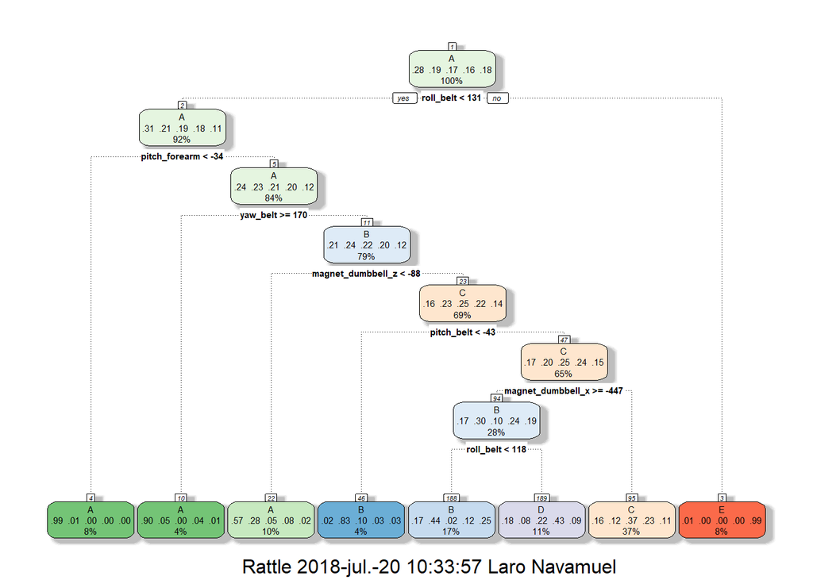

```r
#Model with Classification Tree

trainingControl <- trainControl(method="cv", number=5)

ClassificationTree_Model <- train(classe~., data=TrainSet, method="rpart", trControl=trainingControl)

fancyRpartPlot(ClassificationTree_Model$finalModel)
```

```r
trainPrediction_CT <- predict(ClassificationTree_Model,newdata=TestSet)
confussionMatrixCTModel <- confusionMatrix(TestSet$classe,trainPrediction_CT)

confussionMatrixCTModel$table
```

```
##           Reference
## Prediction   A   B   C   D   E
##          A 870 159 273  88   5
##          B 162 530 214  43   0
##          C  29  36 674 116   0
##          D  46 136 429 193   0
##          E  16 221 224  51 389
```

```r
confussionMatrixCTModel$overall[1]
```

```
##  Accuracy
## 0.5415987
```

Accuracy with Classification Tree model is 0.5415987, so is clear that is more or less like flip a coin to make a prediction. In this case is clear that is needed build another prediction models with best accuracy.

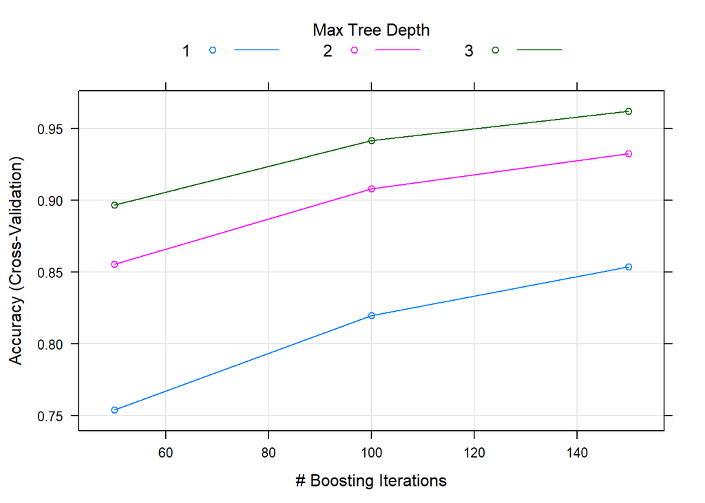

```r
#Model with Gradient Boosting

GBM_Model  <- train(classe ~ ., data=TrainSet, method = "gbm",trControl = trainingControl,verbose=FALSE)

plot(GBM_Model)
```

```r
trainPrediction_GBM<- predict(GBM_Model,newdata=TestSet)
confussionMatrixGBMModel <- confusionMatrix(TestSet$classe,trainPrediction_GBM)

confussionMatrixGBMModel$table
```

```
##           Reference
## Prediction    A    B    C    D    E
##          A 1378   16    1    0    0
##          B   43  880   25    0    1
##          C    0   20  823   11    1
##          D    0    1   28  770    5
##          E    2   10    8   16  865
```

```r
confussionMatrixGBMModel$overall[1]
```

```
##  Accuracy
## 0.9616639
```

Accuracy with gradient boosting model is 0.9616639

```r
#Model with Random Forest

RandomForest_Model <- train(classe ~ ., data=TrainSet, method="rf", trControl=trainingControl, ntree=250,verbose=FALSE)


print(RandomForest_Model)
```

```
## Random Forest
##
## 14718 samples
##    52 predictor
##     5 classes: 'A', 'B', 'C', 'D', 'E'
##
## No pre-processing
## Resampling: Cross-Validated (5 fold)
## Summary of sample sizes: 11775, 11775, 11775, 11773, 11774
## Resampling results across tuning parameters:
##
##   mtry  Accuracy   Kappa
##    2    0.9920504  0.9899438
##   27    0.9927977  0.9908893
##   52    0.9884491  0.9853873
##
## Accuracy was used to select the optimal model using the largest value.
## The final value used for the model was mtry = 27.
```

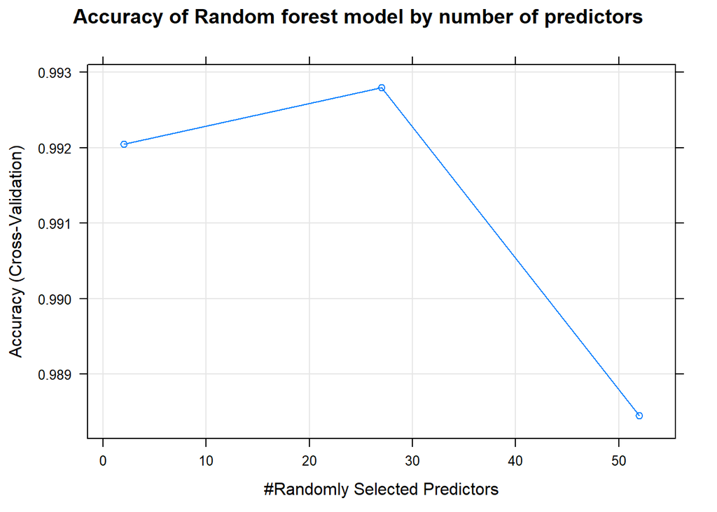

```r
plot(RandomForest_Model,main="Accuracy of Random forest model by number of predictors")
```

```r
trainPrediction_RF <- predict(RandomForest_Model,newdata=TestSet)
confussionMatrixRFModel <- confusionMatrix(TestSet$classe,trainPrediction_RF)


confussionMatrixRFModel$table
```

```
##           Reference
## Prediction    A    B    C    D    E
##          A 1394    1    0    0    0
##          B    6  938    5    0    0
##          C    0    3  848    4    0
##          D    0    0    9  795    0
##          E    0    0    2    5  894
```

```r
confussionMatrixRFModel$overall[1]
```

```
## Accuracy
## 0.992863
```

```r
names(RandomForest_Model$finalModel)
```

```
##  [1] "call"            "type"            "predicted"
##  [4] "err.rate"        "confusion"       "votes"
##  [7] "oob.times"       "classes"         "importance"
## [10] "importanceSD"    "localImportance" "proximity"
## [13] "ntree"           "mtry"            "forest"
## [16] "y"               "test"            "inbag"
## [19] "xNames"          "problemType"     "tuneValue"
## [22] "obsLevels"       "param"
```

```r
RandomForest_Model$finalModel$classes
```

```
## [1] "A" "B" "C" "D" "E"
```

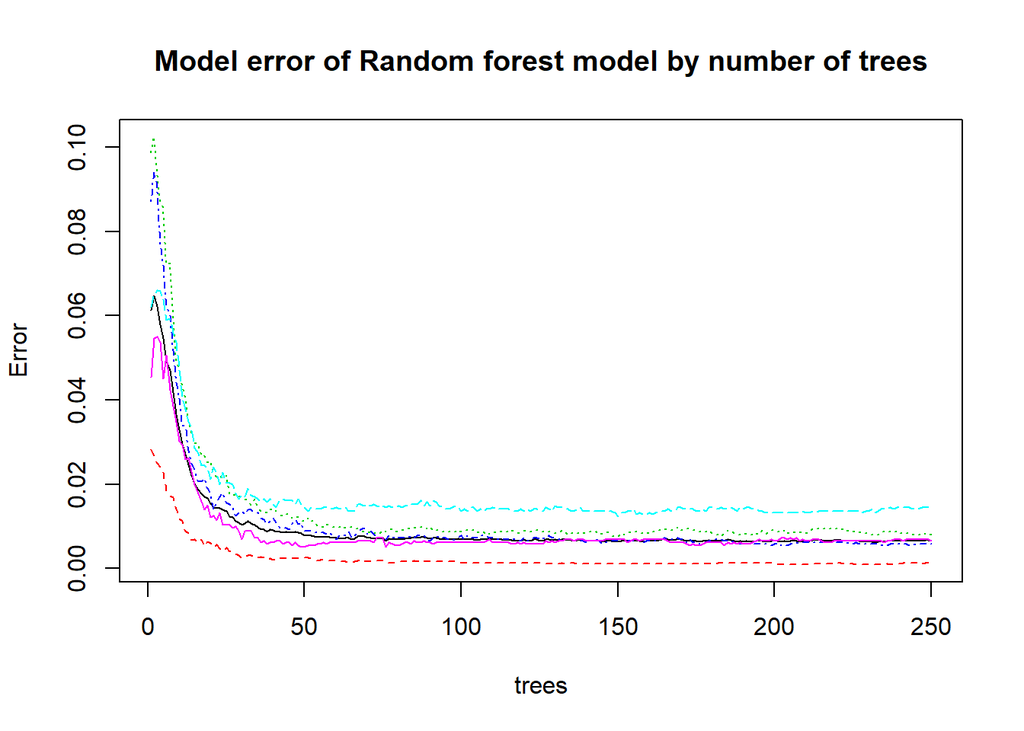

```r
plot(RandomForest_Model$finalModel,main="Model error of Random forest model by number of trees")
```

```r
Variables_Significancy <- varImp(RandomForest_Model)
Variables_Significancy
```

```
## rf variable importance
##
##   only 20 most important variables shown (out of 52)
##
##                      Overall
## roll_belt            100.000
## pitch_forearm         58.020
## yaw_belt              54.618
## pitch_belt            44.446
## magnet_dumbbell_z     43.163
## magnet_dumbbell_y     39.235
## roll_forearm          36.843
## accel_dumbbell_y      20.543
## magnet_dumbbell_x     20.073
## roll_dumbbell         19.756
## accel_forearm_x       17.086
## magnet_belt_y         14.836
## magnet_belt_z         14.825
## accel_dumbbell_z      13.823
## magnet_forearm_z      13.225
## total_accel_dumbbell  12.563
## accel_belt_z          11.457
## yaw_arm               10.317
## magnet_belt_x         10.064
## gyros_belt_z           9.827
```

Accuracy with random forest model is 0.992863

# Conclusions

Based in previous accuracy values, is clear that best models are GBM and Random Forest. With random forest, model reach an accuracy of 0.992863 using Cross-Validation method with 5 folds - steps, so is the best model to do final prediction.

The optimal number of predictors is 27. There is no significal increase of the accuracy with 2 predictors and 27, but the slope decreases more with more than 27 predictors (even if the accuracy remains very good). The fact that not all the accuracy is worse using all the available predictors suggest that maybe exists some dependencies between them.

**Final Prediction for 20 Test Cases.**

```r
Final_Prediction <- predict(RandomForest_Model,newdata=TestDataClean)
```

Results for final prediction:

B, A, B, A, A, E, D, B, A, A, B, C, B, A, E, E, A, B, B, B